# Lab 05 - Halloween Candies & Data Viz Improvement

Chenxi Li

2026-11-01

### Load packages

```r
library(tidyverse)
library(ggplot2)
```

# Questioning data visualisations

## Image 1

The bar lengths are not proportional to the stated values. For example, English has about 1.64 times as many speakers as Spanish, but their bars appear almost equal in length. The Chinese bar is also much thicker, which exaggerates its visual prominence. The chart does not clearly specify the year, source, or definition of “speakers”. A sorted horizontal bar chart with consistent widths, a zero baseline and a common unit would make comparisons clearer.

## Image 2

The chart does not explain how angle and radius represent the two variables. Sector areas combine both dimensions, making comparisons difficult. A labelled scatter plot would show the relationship between total area and population density more clearly.

## Image 3

The scatter plot is suitable for showing an association, but overlapping points and labels make it difficult to read. Clear scales and legends are needed. The positive association does not establish that stronger rule of law causes higher life expectancy.

## Image 4

The chart provides useful information about the global income distribution, but stacked regions are difficult to compare because they do not share a common baseline. The logarithmic income scale also requires careful explanation. Separate density plots would make regional distributions easier to compare, while the stacked chart is useful for showing their contributions to the global population.

# Data Visualization for Halloween

Ensure that you have the following two lines of code at the top of `lab-05.Rmd` to make the commands available to you.

```r
library(tidyverse)
library(ggplot2)

# Install that package first
# install.packages("fivethirtyeight")
library(fivethirtyeight)
```

```r
candy_df <- candy_rankings
glimpse(candy_df)
```

```
## Rows: 85
## Columns: 13
## $ competitorname   <chr> "100 Grand", "3 Musketeers", "One dime", "One quarter…
## $ chocolate        <lgl> TRUE, TRUE, FALSE, FALSE, FALSE, TRUE, TRUE, FALSE, F…
## $ fruity           <lgl> FALSE, FALSE, FALSE, FALSE, TRUE, FALSE, FALSE, FALSE…
## $ caramel          <lgl> TRUE, FALSE, FALSE, FALSE, FALSE, FALSE, TRUE, FALSE,…
## $ peanutyalmondy   <lgl> FALSE, FALSE, FALSE, FALSE, FALSE, TRUE, TRUE, TRUE, …
## $ nougat           <lgl> FALSE, TRUE, FALSE, FALSE, FALSE, FALSE, TRUE, FALSE,…
## $ crispedricewafer <lgl> TRUE, FALSE, FALSE, FALSE, FALSE, FALSE, FALSE, FALSE…
## $ hard             <lgl> FALSE, FALSE, FALSE, FALSE, FALSE, FALSE, FALSE, FALS…
## $ bar              <lgl> TRUE, TRUE, FALSE, FALSE, FALSE, TRUE, TRUE, FALSE, F…
## $ pluribus         <lgl> FALSE, FALSE, FALSE, FALSE, FALSE, FALSE, FALSE, TRUE…
## $ sugarpercent     <dbl> 0.732, 0.604, 0.011, 0.011, 0.906, 0.465, 0.604, 0.31…
## $ pricepercent     <dbl> 0.860, 0.511, 0.116, 0.511, 0.511, 0.767, 0.767, 0.51…
## $ winpercent       <dbl> 66.97173, 67.60294, 32.26109, 46.11650, 52.34146, 50.…
```

## Exercise 1

How many observations and variables are in this dataset? Did you identify the type of variables, remember that this detail is crucial to create which kind of data visualization in general.

The dataset contains 85 observations and 13 variables. Each observation represents one candy or competing item. There is one character variable (`competitorname`), nine logical variables describing binary characteristics, and three numerical variables (`sugarpercent`, `pricepercent`, and `winpercent`).

Variable types help determine the appropriate visualisation. For example, bar charts can show counts of categorical values, histograms can show numerical distributions, and scatter plots can show relationships between two numerical variables.

# Data viz - One variable at a time

Just to use the logical variables as categories, run the following code chunk first!

```r
candy_df <- candy_df %>%
  mutate(across(where(is.logical), as_factor))
```

## Exercise 2

Complete the following code to get the data viz to represent “how many candies contain caramel via bar plot”. Fill in the blanks, remove the # symbol in front of your code and the execute the code chunk via green play button.

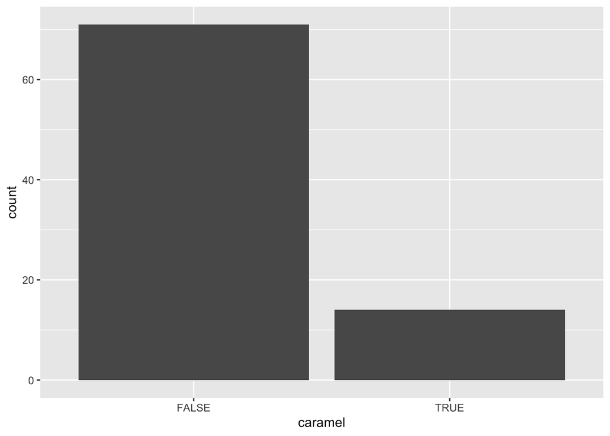

```r
ggplot(candy_rankings, aes(x = caramel)) +
  geom_bar()
```

Most candies in this dataset do not contain caramel. The bar for FALSE is much taller than the bar for TRUE, indicating that candies without caramel are more common in this dataset.

- How many candies contain chocolate?

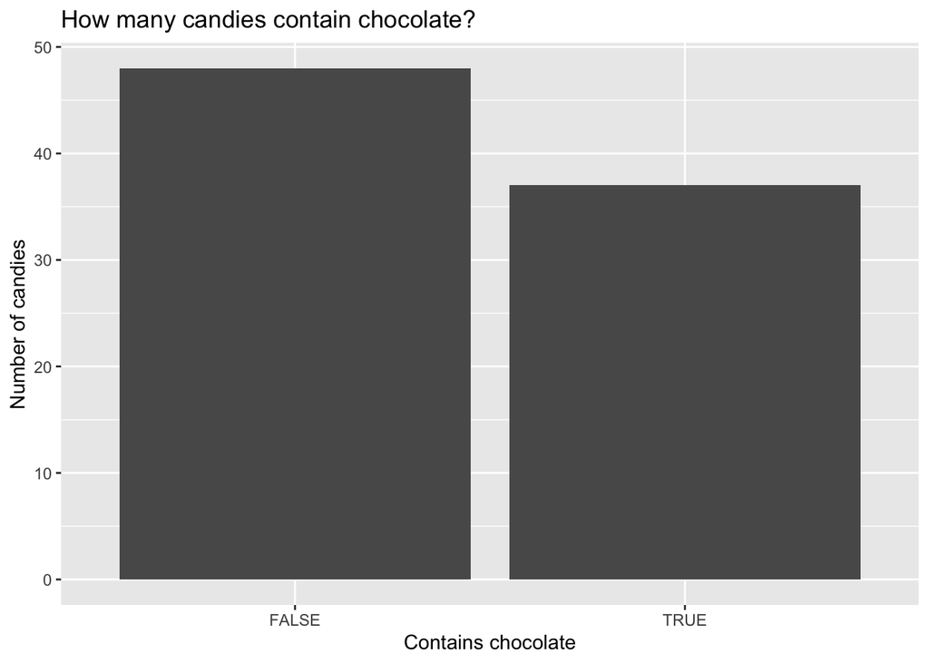

```r
ggplot(candy_df, aes(x = chocolate)) +
  geom_bar() +
  labs(
    title = "How many candies contain chocolate?",
    x = "Contains chocolate",
    y = "Number of candies"
  )
```

Candies without chocolate are more common than candies with chocolate in this dataset. However, the difference between the two groups is smaller than the difference between candies with and without caramel.

## Exercise 3

Now look at a numerical variable, such as `winpercent`. Create an histogram for this variable using ggplot2 functions below. Include informative x and y labels and a title, as a good practice.

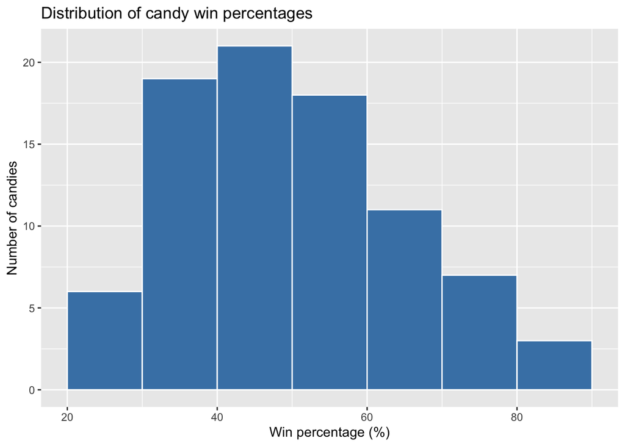

```r
ggplot(candy_df, aes(x = winpercent)) +
  geom_histogram(binwidth = 10, boundary = 0,
                 fill = "steelblue", colour = "white") +
  labs(
    title = "Distribution of candy win percentages",
    x = "Win percentage (%)",
    y = "Number of candies"
  )
```

Most candies have win percentages between 30% and 60%, with the highest frequency in the 40%–50% interval. The distribution is unimodal and slightly right-skewed, with relatively few candies having very high win percentages.

- Play with the binwidth or bins parameter in the new version by using binwidth = 20.

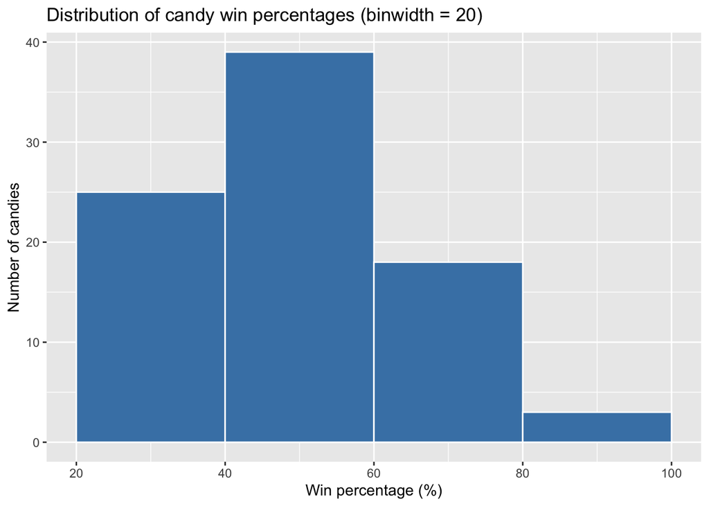

```r
ggplot(candy_df, aes(x = winpercent)) +
  geom_histogram(binwidth = 20, boundary = 0,
                 fill = "steelblue", colour = "white") +
  labs(
    title = "Distribution of candy win percentages (binwidth = 20)",
    x = "Win percentage (%)",
    y = "Number of candies"
  )
```

Increasing the bin width from 10 to 20 produces fewer, wider bars. For example, the 40%–50% and 50%–60% intervals are combined into one 40%–60% interval containing 39 candies. The overall pattern remains visible, but finer details are lost. The underlying data and total number of candies remain unchanged.

# Data viz - more than one variable

## Exercise 4

How about using the both variables; chocolate vs winpercent? Run the following incomplete code snippet to get a faceted visualization.

Fill in the blanks, remove the # symbol in front of your code and the execute the code chunk via green play button.

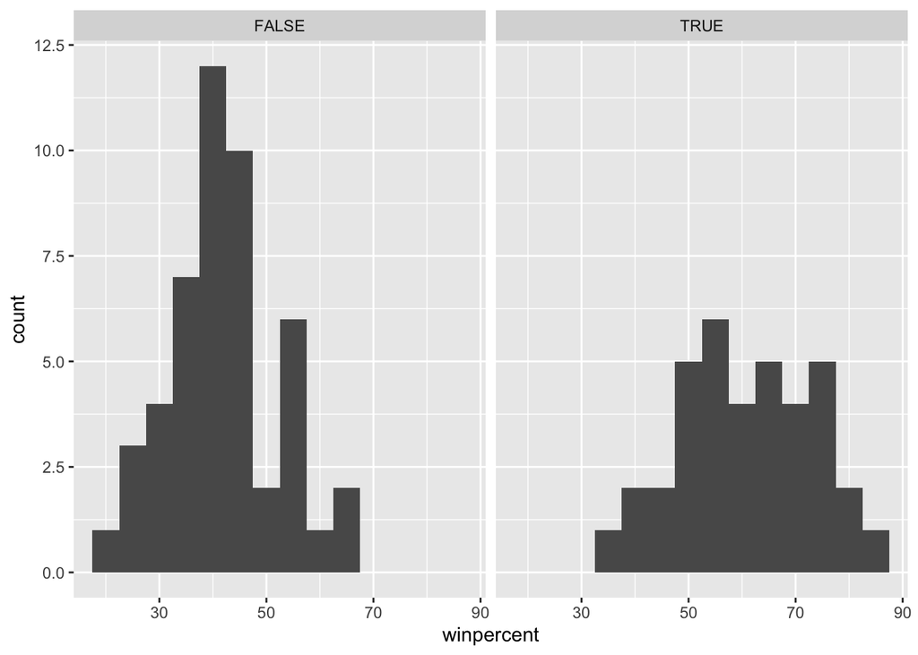

```r
ggplot(candy_df, aes(x = winpercent)) +
  geom_histogram(binwidth = 5) +
  facet_wrap(~chocolate)
```

- Consider adding the `fill = caramel` within the aes() vs. geom_histogram(), what do you get?

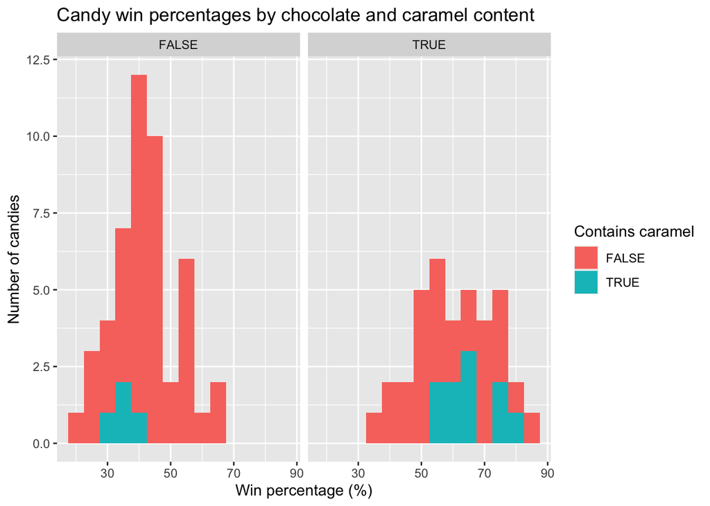

```r
ggplot(candy_df, aes(x = winpercent, fill = caramel)) +
  geom_histogram(binwidth = 5) +
  facet_wrap(~chocolate) +
  labs(
    title = "Candy win percentages by chocolate and caramel content",
    x = "Win percentage (%)",
    y = "Number of candies",
    fill = "Contains caramel"
  )
```

Inside aes(), fill = caramel maps caramel content to different colours, producing stacked histograms with a legend. Outside aes(), a fixed fill value such as “steelblue” gives all bars the same colour and does not represent caramel content.

## Exercise 5

Create a visualization that examines the relationship between a candy’s win percentage and whether it contains chocolate. Include x and y labels and a title. Describe any relationship you see.

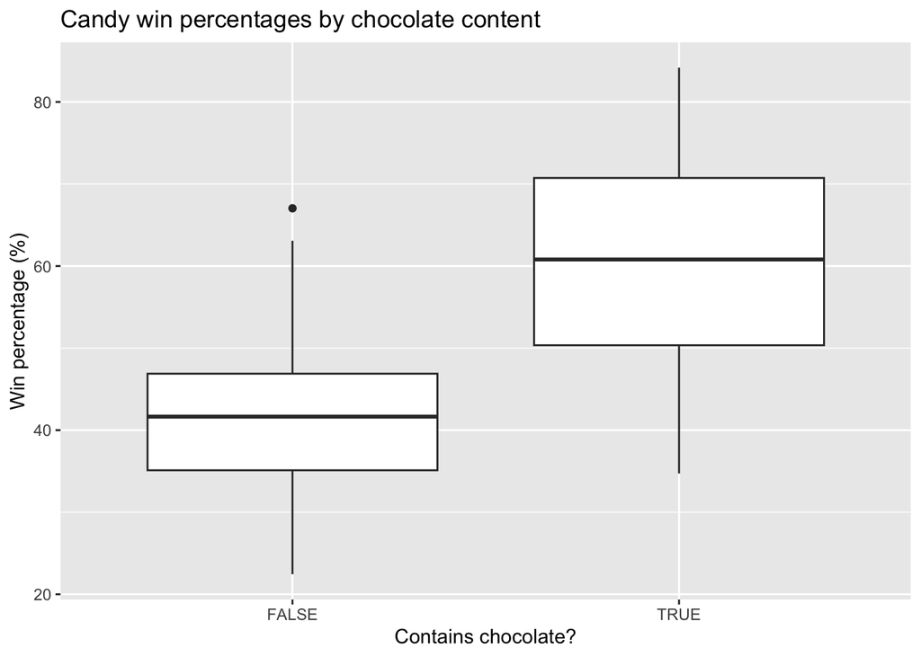

```r
ggplot(candy_df, aes(x = chocolate, y = winpercent)) +
  geom_boxplot() +
  labs(
    title = "Candy win percentages by chocolate content",
    x = "Contains chocolate?",
    y = "Win percentage (%)"
  )
```

Candies containing chocolate tend to have higher win percentages. Their median win percentage is approximately 60.8%, compared with 41.6% for candies without chocolate, a difference of 19.2 percentage points. The chocolate group also has a larger interquartile range. However, the groups overlap, and this association does not establish causation.

- Consider the similar pair by replacing chocolate with caramel, fruity and compare their results.

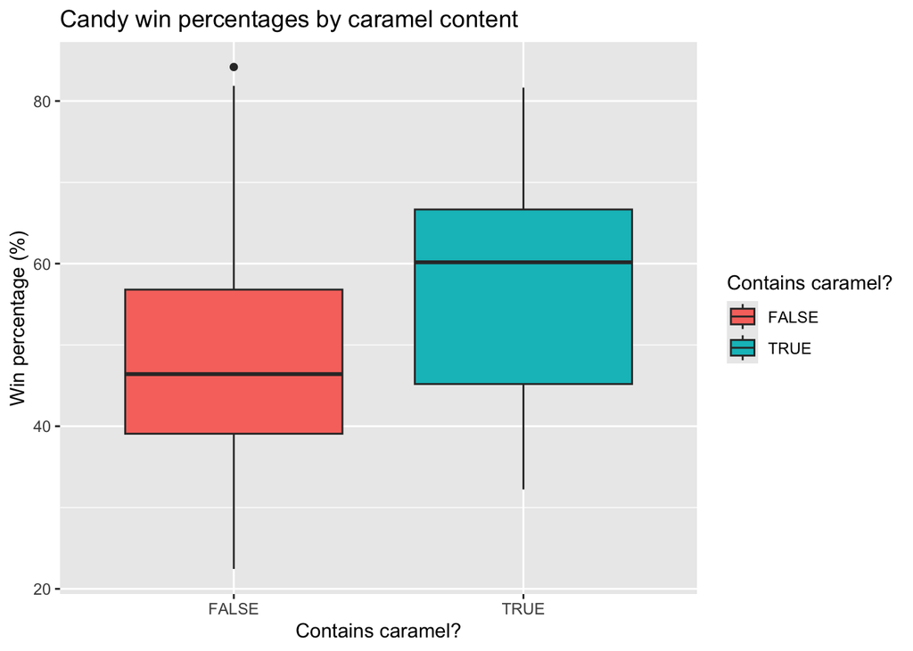

```r
ggplot(candy_df, aes(x = caramel, y = winpercent, fill = caramel)) +
  geom_boxplot() +
  labs(
    title = "Candy win percentages by caramel content",
    x = "Contains caramel?",
    y = "Win percentage (%)",
    fill = "Contains caramel?"
  )
```

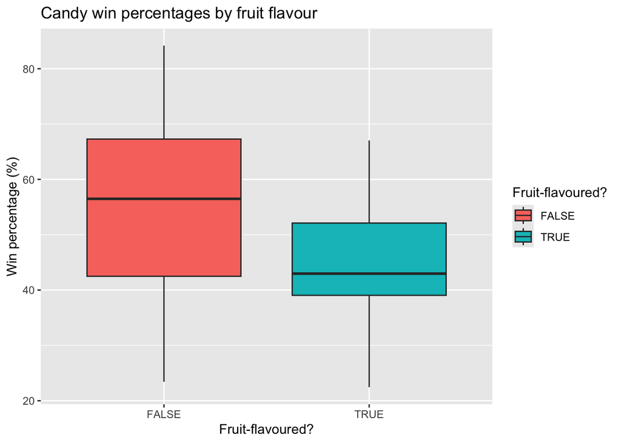

```r
ggplot(candy_df, aes(x = fruity, y = winpercent, fill = fruity)) +
  geom_boxplot() +
  labs(
    title = "Candy win percentages by fruit flavour",
    x = "Fruit-flavoured?",
    y = "Win percentage (%)",
    fill = "Fruit-flavoured?"
  )
```

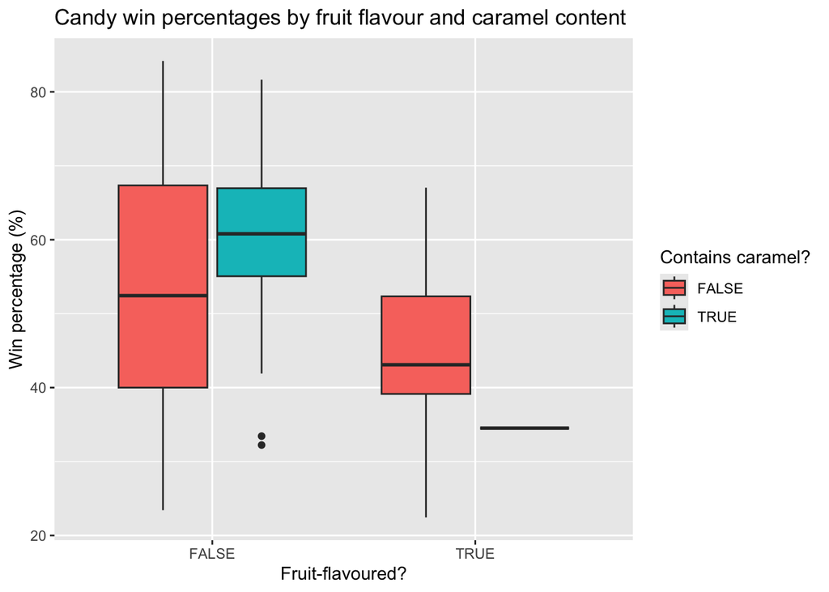

```r
ggplot(candy_df,
       aes(x = fruity, y = winpercent, fill = caramel)) +
  geom_boxplot() +
  labs(
    title = "Candy win percentages by fruit flavour and caramel content",
    x = "Fruit-flavoured?",
    y = "Win percentage (%)",
    fill = "Contains caramel?"
  )
```

- Also include summary statistics details for this discussion by using the calculation below:

```r
candy_rankings %>%
  group_by(chocolate) %>%
  summarise(
    n = n(),
    mean_win = mean(winpercent),
    median_win = median(winpercent)
  )
```

```
## # A tibble: 2 × 4
##   chocolate     n mean_win median_win
##   <lgl>     <int>    <dbl>      <dbl>
## 1 FALSE        48     42.1       41.6
## 2 TRUE         37     60.9       60.8
```

## Exercise 6

Do more expensive candies win more often? Make a scatterplot of pricepercent (x) against winpercent (y). Describe their relationship.

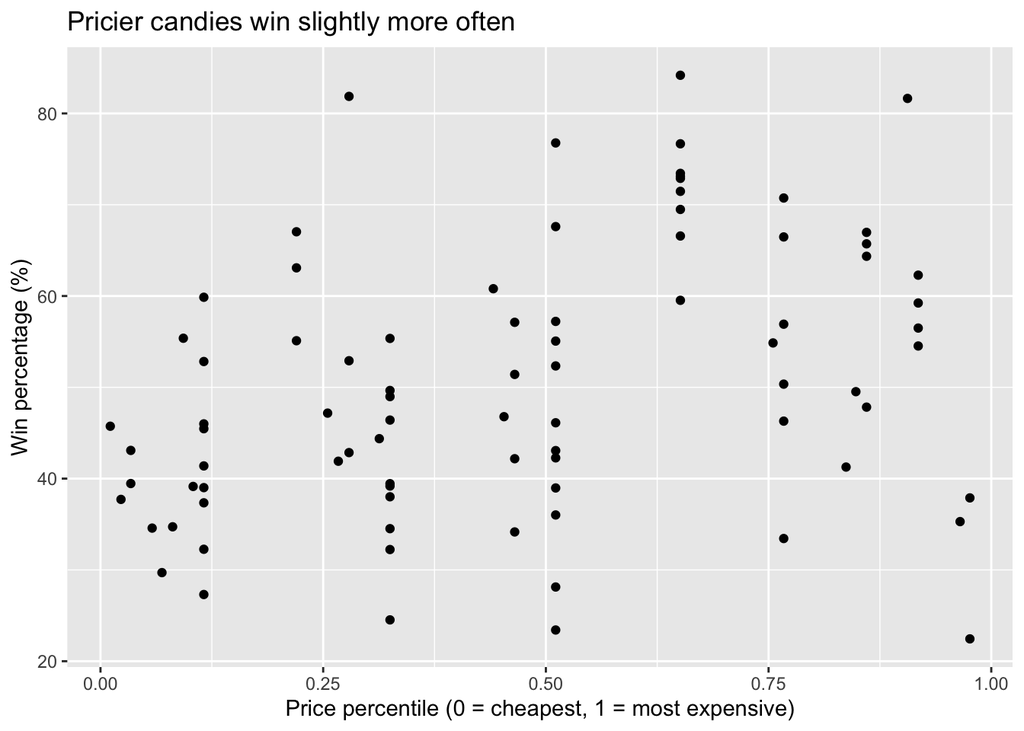

```r
ggplot(candy_df, aes(x = pricepercent, y = winpercent)) +
  geom_point() +
  labs(
    title = "Pricier candies win slightly more often",
    x = "Price percentile (0 = cheapest, 1 = most expensive)",
    y = "Win percentage (%)"
  )
```

There is a positive association between price percentile and win percentage, although the points are widely scattered. More expensive candies tend to win more often, but there are many exceptions. Price alone does not reliably predict a candy’s win percentage.

- Add `color = chocolate` to add a third variable to the created visualization

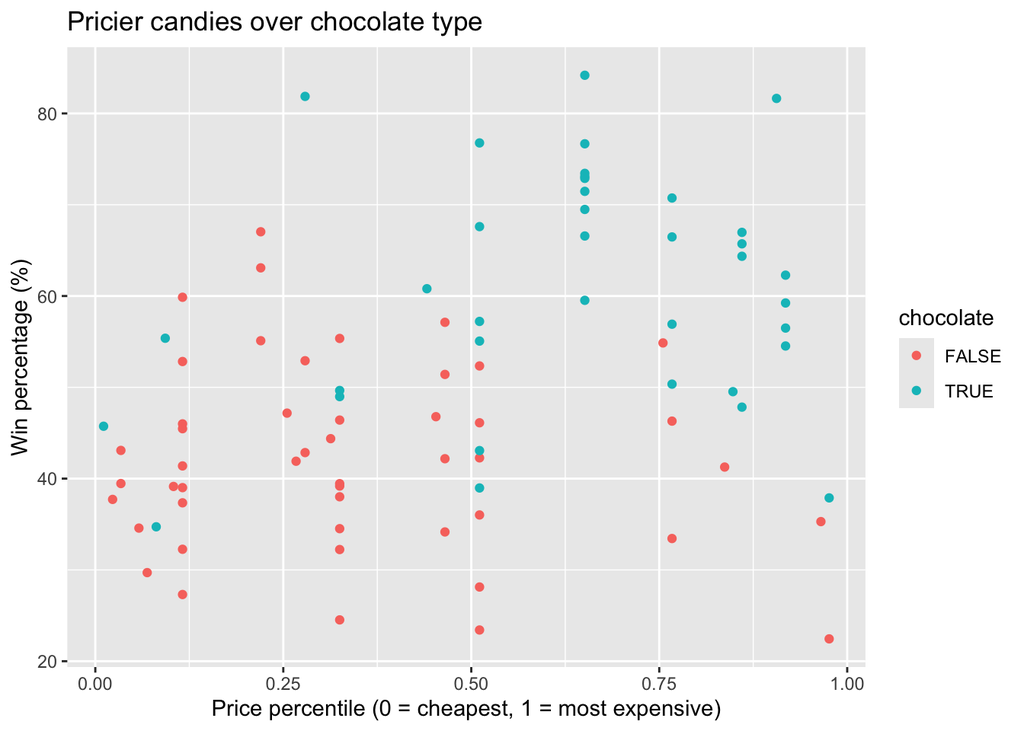

```r
ggplot(candy_df, aes(x = pricepercent, y = winpercent, color = chocolate)) +
  geom_point() +
  labs(
    title = "Pricier candies over chocolate type",
    x = "Price percentile (0 = cheapest, 1 = most expensive)",
    y = "Win percentage (%)"
  )
```

Colouring the points by chocolate content reveals that chocolate candies tend to have both higher price percentiles and higher win percentages. Chocolate content may therefore partly account for the overall association between price and win percentage. The plot does not show that increasing price causes a candy to become more popular.

- How to facet this by using another categorical variable such as `bar`?

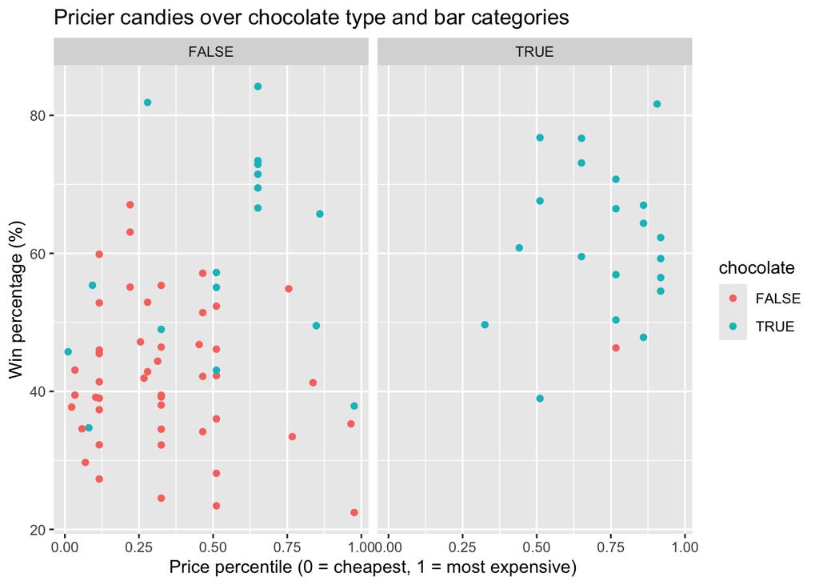

```r
ggplot(candy_df, aes(x = pricepercent, y = winpercent, color = chocolate)) +
  geom_point() +
  facet_grid(~ bar) +
  labs(
    title = "Pricier candies over chocolate type and bar categories",
    x = "Price percentile (0 = cheapest, 1 = most expensive)",
    y = "Win percentage (%)"
  )
```

Most bar-shaped candies contain chocolate and have relatively high price percentiles. Non-bar candies include a wider mixture of chocolate and non-chocolate products. Within each panel, the relationship between price and win percentage is less clear, suggesting that candy characteristics should be considered alongside price.

## Exercise 7

Are chocolate candies more likely to be candy bars? Make a filled bar plot with chocolate on the x-axis and fill = bar. Describe what you see.

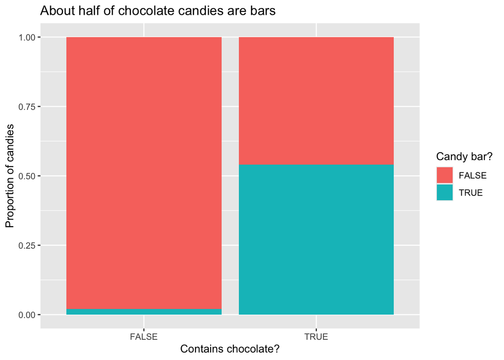

```r
ggplot(candy_df, aes(x = chocolate, fill = bar)) +
  geom_bar(position = "fill") +
  labs(
    title = "About half of chocolate candies are bars",
    x = "Contains chocolate?",
    y = "Proportion of candies",
    fill = "Candy bar?"
  )
```

Chocolate candies are much more likely to be bars in this dataset. Approximately 54% of chocolate candies are bars, compared with about 2% of non-chocolate candies. Each bar represents 100% of its chocolate category, so the chart compares proportions rather than counts.

## Exercise 8

Create a new variable called price per sugar ratio as the division of pricepercent and sugarpercent. Plot it against winpercent, and set the color of all points to blue for the competitors who are not “One dime” or “One quarter”. Include x and y labels and a title. Describe any relationship you see.

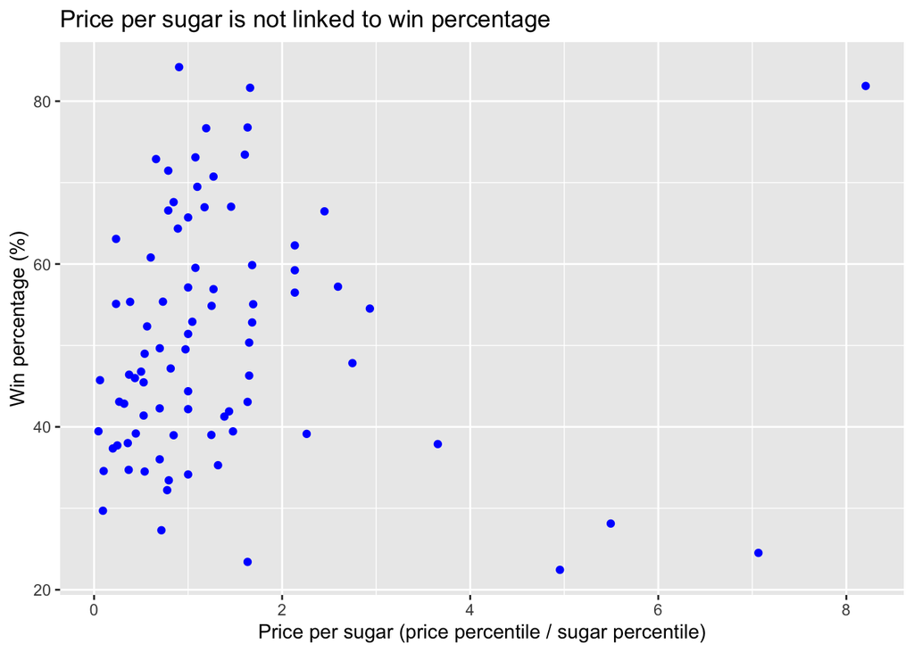

```r
candy_rankings <- candy_rankings %>%
  mutate(price_per_sugar = pricepercent / sugarpercent)

candy_rankings %>%
  filter(!competitorname %in% c("One dime", "One quarter")) %>%
  ggplot(aes(x = price_per_sugar, y = winpercent)) +
  geom_point(color = "blue") +
  labs(
    title = "Price per sugar is not linked to win percentage",
    x = "Price per sugar (price percentile / sugar percentile)",
    y = "Win percentage (%)"
  )
```

The scatter plot shows no clear relationship between the price-to-sugar percentile ratio and win percentage. Most candies have ratios below approximately 2, but their win percentages vary widely. A few candies have much larger ratios, with both high and low win percentages. This ratio compares percentile measures rather than actual price per unit of sugar.

## Exercise 9

Modify your plot in Exercise 8 to facet by whether a candy is bar-shaped. Have the color reflect whether the candy is fruity or not. The plot must include x and y labels along with a title. How do these plots compare to each other?

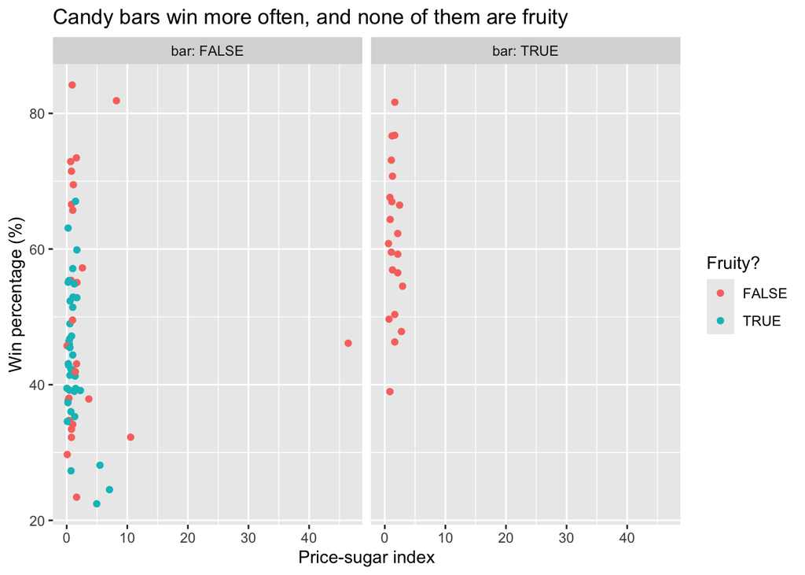

```r
ggplot(candy_rankings, aes(x = price_per_sugar, y = winpercent, color = fruity)) +
  geom_point() +
  facet_wrap(~ bar, labeller = label_both) +
  labs(
    title = "Candy bars win more often, and none of them are fruity",
    x = "Price-sugar index",
    y = "Win percentage (%)",
    color = "Fruity?"
  )
```

Bar-shaped candies generally have higher win percentages than non-bar candies, although the groups overlap. All bar-shaped candies in this dataset are non-fruity, while non-bar candies include both fruity and non-fruity varieties. Neither panel shows a clear relationship between the price-to-sugar percentile ratio and win percentage. Faceting and colour reveal group differences that were hidden in the original plot.

# Take a sad plot and make it better!

```r
staff <- read_csv("data/instructional-staff.csv")
```

## Exercise 1

- What is the difference between *wide format* data and *long format* data?
- Is the format `staff` data *wide* or *long*?
- How many observations are there in the data set?

In wide format, measurements for different years are stored in separate columns. In long format, the years are stored in one column and the corresponding values in another, with one row per faculty-type–year combination.

The staff dataset is in wide format. It has 5 rows and 12 columns: one faculty-type column and 11 year columns. Taking each faculty-type–year combination as an observation, there are 5 × 11 = 55 observations, which would occupy 55 rows in long format.

## Exercise 2

```r
staff_long <- staff %>%
  pivot_longer(
    cols = c("1975", "1989", "1993", "1995", "1999", "2001",
             "2003", "2005", "2007", "2009", "2011"),
    names_to = "year",
    values_to = "percent"
    )
```

The staff_long dataset has 55 rows and 3 columns: faculty_type, year, and percent. Each row represents one faculty type in one year. This matches the 55 observations identified in Exercise 1: 5 faculty types × 11 years.

## Exercise 3

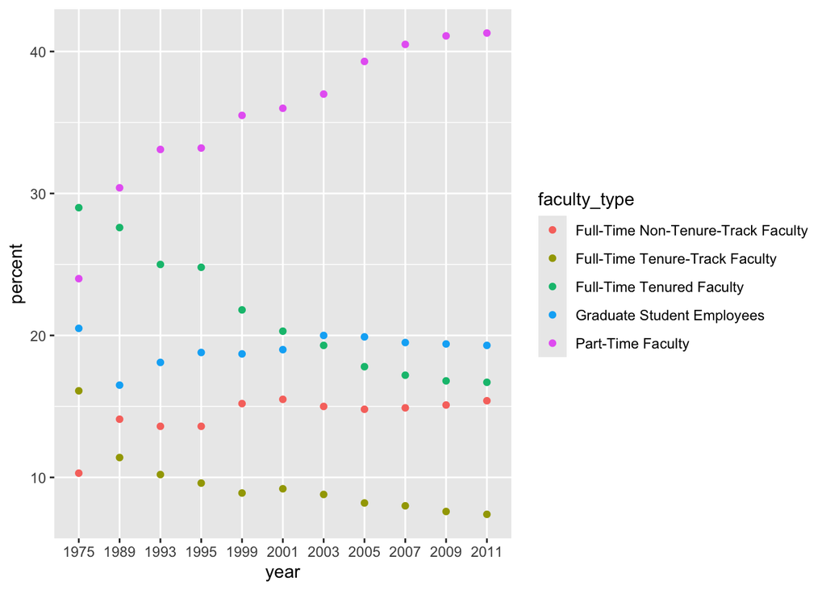

```r
ggplot(data = staff_long,
       mapping = aes(x = year,
                     y = percent,
                     colour = faculty_type)) +
  geom_point()
```

## Exercise 4

```
## `geom_line()`: Each group consists of only one observation.
## ℹ Do you need to adjust the group aesthetic?
```

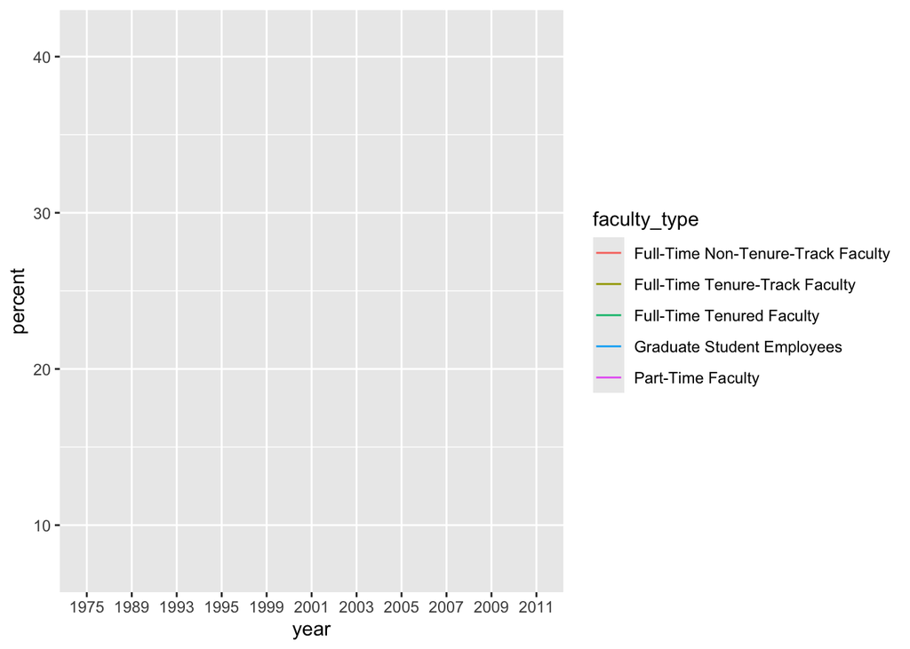

```r
ggplot(data = staff_long,
       mapping = aes(x = year,
                     y = percent,
                     colour = faculty_type)) +
  geom_line()
```

Note that the lines in this plot do not appear! This is because the type of variable year is character.

## Exercise 5

```r
staff_long <- staff_long %>%
  mutate(year = as.numeric(year))
```

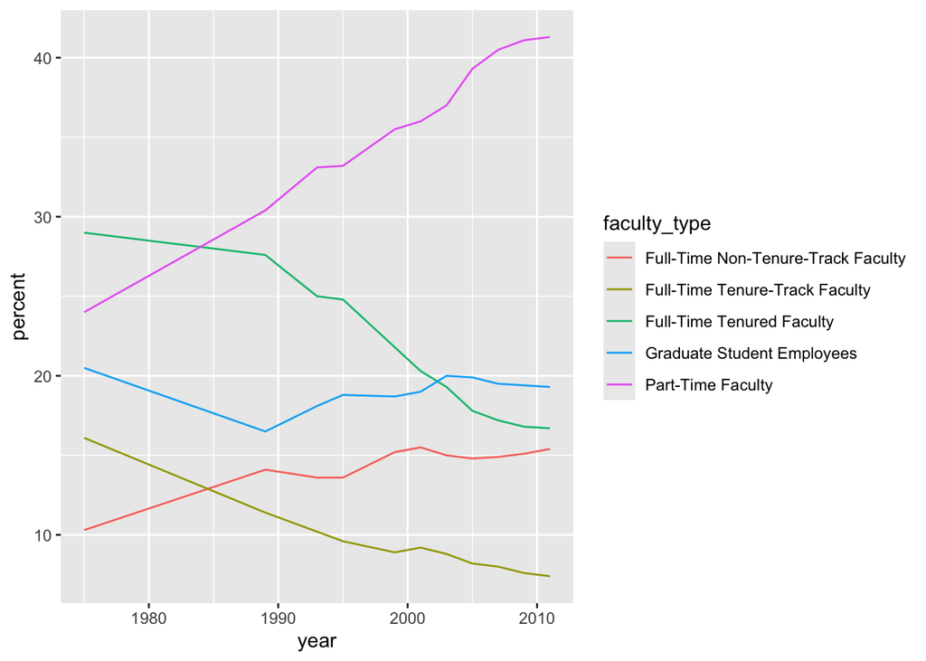

```r
ggplot(data = staff_long,
       mapping = aes(x = year,
                     y = percent,
                     colour = faculty_type)) +
  geom_line()
```

## Exercise 6

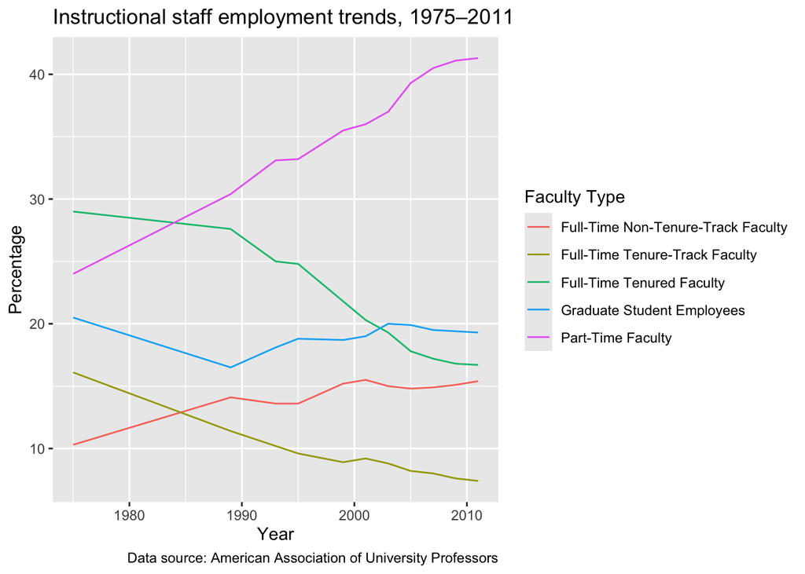

```r
ggplot(data = staff_long,
       mapping = aes(x = year,
                     y = percent,
                     colour = faculty_type)) +
  geom_line() +
  labs(
    title = "Instructional staff employment trends, 1975–2011",
    x = "Year",
    y = "Percentage",
    colour = "Faculty Type",
    caption = "Data source: American Association of University Professors"
  )
```

## Exercise 7

I would highlight part-time faculty in red and display the other staff types in grey. This would draw attention to the increase in the part-time share while retaining the other trends for comparison. I would also use a clear title, a minimal theme and a legend below the plot.

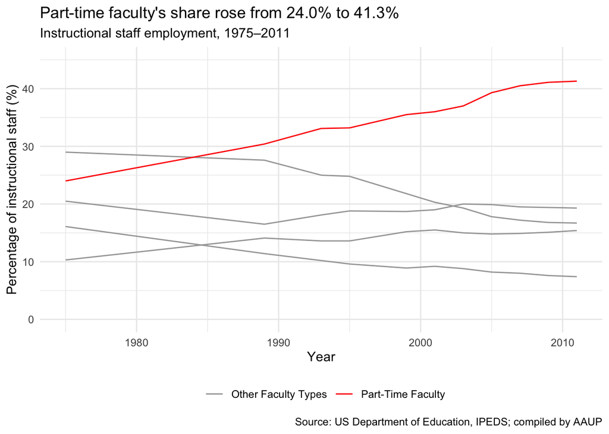

```r
staff_long <- staff_long %>%
  mutate(
    part_time = case_when(
      faculty_type == "Part-Time Faculty" ~ "Part-Time Faculty",
      TRUE ~ "Other Faculty Types"
    )
  )
ggplot(staff_long,
       aes(x = year,
           y = percent,
           group = faculty_type,
           colour = part_time)) +
  geom_line() +
  scale_colour_manual(
    values = c(
      "Other Faculty Types" = "grey65",
      "Part-Time Faculty" = "red"
    )
  ) +
  theme_minimal() +
  labs(
    title = "Part-time faculty's share rose from 24.0% to 41.3%",
    subtitle = "Instructional staff employment, 1975–2011",
    x = "Year",
    y = "Percentage of instructional staff (%)",
    colour = "",
    caption = "Source: US Department of Education, IPEDS; compiled by AAUP"
  ) +
  coord_cartesian(ylim = c(0, 45)) +
  theme(legend.position = "bottom")
```

I highlighted part-time faculty in red and kept the other four staff categories as separate grey lines for comparison. A minimal theme and a bottom legend reduce visual clutter, while the title states the main finding. The proportion of part-time faculty increased from 24.0% in 1975 to 41.3% in 2011, an increase of 17.3 percentage points.